# Trabralho AV1

Erick Brito e Vinícius Mitsuo

# Projeto

Os Esportes Eletrônicos ou apenas eSports, como é mundialmente conhecido, vêm dominando o mundo gamer e tecnológico. Numa definição simples, os eSports giram em torno de competições de jogos eletrônicos em que atletas profissionais disputam partidas, seja presencial ou on-line. Na maioria delas, os espectadores estão presentes no local do evento ou em plataformas de streaming.

Dado o crescimento dos Esportes Eletrônicos, assim como o crescimento desse mercado, decidimos então realizar uma análise exploratória de dados e visualizações em uma base de dados de partidas oficiais de um jogo específico, chamado Counter Strike: Global Offensive, ou CS:GO para os mais íntimos.

## Motivação

A sensação dos Esportes Eletrônicos fez com que cada vez mais empresas/organizações se interessassem e investissem nesse mercado. No caso do CS:GO, isso não é diferente.

Hoje em dia existem organizações gigantes participando do cenário competitivo de CS:GO, como por exemplo, Team Liquid, FaZe Clan, TSM, entre outras mais, que são muito valiosas e possuem times profissionais excelentes. Essas organizações estão constantemente alterando o elenco de seus times e procurando um meio de se sobressair no cenário competitivo.

Alterar um time, buscar uma melhora técnica em jogo, criar táticas, tudo isso depende de informações, depende de estar seguindo o meta – Meta pode ser usado como um acrônimo para “most effective tactics available”, em português “táticas mais eficazes disponíveis”, e chamar algo de “meta” significa que é uma maneira eficaz de atingir o objetivo do jogo, seja vencer outros jogadores ou vencer o próprio jogo.

Portanto, uma análise de dados trazendo informações sobre o jogo(parte tática e mecânica) e sobre os jogadores se faz necessária e é de interesse de organizações/empresas que estão nesse meio. Daí, nossa motivação para começar esse projeto.

## Base de Dados

A base de dados que escolhemos está disponível em [CS:GO Professional Matches](https://www.kaggle.com/datasets/mateusdmachado/csgo-professional-matches?select=players.csv).

Nessa base temos as seguintes tabelas:

- **results.csv**: com as pontuações do mapa e classificações da equipe
- **picks.csv**: com a ordem de escolha de mapas e vetos no processo de seleção de mapas.
- **economy.csv**: com o valor do equipamento inicial da rodada para todas as rodadas jogadas em um partida
- **players.csv**: com as performances individuais dos jogadores em cada mapa.

## Lendo as Bases

Usando a função read.csv2() do R Base, conseguimos ler e salvar em variáveis as nossas tabelas.

```r
### Usando uma função do R Base para ler os csvs e assim os armazenamos nas seguintes variáveis
# setwd("/home/erick/Documents/MAP/5prd/Introdução ao R aplicado em Ciência de Dados/A1")
players <- read.csv2("players.csv", sep=",")
results <- read.csv2("results.csv", sep=",")
picks <- read.csv2("picks.csv", sep=",")
economy <- read.csv2("economy.csv", sep=",")

### Transformando em tibble
players <- as_tibble(players)
results <- as_tibble(results)
picks <- as_tibble(picks)
economy <- as_tibble(economy)
```

Dando uma olhada

```r
head(players[1:4],1)
```

```
## # A tibble: 1 × 4
##   date       player_name team          opponent
##   <chr>      <chr>       <chr>         <chr>
## 1 2020-02-26 Brehze      Evil Geniuses Liquid
```

## Limpeza dos dados

Analisando os dados, percebemos que haviam alguns vazios, apenas como ““. Então, decidimos verificar quantas linhas com vazio tem cada coluna:

- **players_empty_strings**: tibble que contém a soma das linhas com “” na tabela **players.cs** por coluna.
- **results_empty_strings**: tibble que contém a soma das linhas com “” na tabela **results.csv** por coluna.
- **picks_empty_strings**: tibble que contém a soma das linhas com “” na tabela **picks.csv** por coluna.
- **economy_empty_strings**: tibble que contém a soma das linhas com “” na tabela **economy.csv** por coluna.

```r
### Verificamos a soma de dados que estão da forma "" para cada coluna

### (Obs: a função funs() foi descontinuada, mas usando as funções similares
### recomendadas não conseguimos o mesmo resultado, algumas até geraram erros.)

players_empty_strings <- players %>%
  summarise_all(funs(sum(. == "")))

results_empty_strings <- results %>%
  summarise_all(funs(sum(. == "")))

picks_empty_strings <- picks %>%
  summarise_all(funs(sum(. == "")))

economy_empty_strings <- economy %>%
  summarise_all(funs(sum(. == "")))
```

Com isso, conseguimos ter uma noção de quantas observações(linhas) podemos remover para que assim alcancemos a base limpa.

Observando **results_empty_strings** e **picks_empty_strings** percebemos que elas já estão limpas e prontas para uso. Mas ao observar as **players_empty_strings**(o mesmo ocorre para **economy_empty_strings**) temos, em grandes quantidades até, dados faltando em algumas colunas:

```r
players_empty_strings[10:15]
```

```
## # A tibble: 1 × 6
##   best_of map_1  map_2  map_3 kills assists
##     <int> <int>  <int>  <int> <int>   <int>
## 1       0     0 186794 314639     0       0
```

Como por exemplo as colunas *map_2* e *map_3*, que mostram quais foram os segundos e terceiros mapas jogados em uma partida. Isso só mostra que existe uma grande quantidade de partidas que não possui segundo e terceiro mapa na nossa base de dados, mas com isso já temos um direcionamento para alcançar a base limpa.

Com essas informações e usando também do nosso conhecimento sobre algumas coisas do jogo, uma limpeza que pode ser feita de já, é remover algumas colunas que já sabemos que não vão ser necessárias para a análise,

```r
### Aqui estamos removendo colunas que estão com grande quantidade de dados faltando
### e que não virão a ser tão utilizadas.
players <- players %>%
  select(-flash_assists, -kast, -adr,-c(m1_kills:m3_rating_t)) %>%
  subset(player_name!="")

### Removendo colunas que não importarão para nossa análise, decidimos analisar
### só certos rounds, que acontecem de certo em uma partida. No CS:GO uma partida
### tem até 30 rounds no "tempo regulamentar", podendo ter muito mais caso essa
### partida vá pro overtime. Mas de certo, 16 rounds ocorrem em qualquer partida
### então decidimos analisar apenas esses.
economy <- economy %>%
  select(-c(X17_t1:X30_t1), -c(X17_t2:X30_t2), -c(X17_winner:X30_winner))
```

## Análises

### Mapa CT ou TR ?

Uma discussão bastante recorrente no cenário do CS:GO, é a dúvida sobre qual mapa é mais CT-sided ou T-sided. Ou seja, se o mapa em questão é mais fácil de atacar para os terroristas, ou se é mais fácil defender para os contra-terroristas. Essa questão é bastante essencial no cenário competitivo, já que ao ter o conhecimento sobre isso, o time que tem a opção de escolher o mapa irá na maioria da vezes optar por escolher o lado mais fácil, para além de começar pontuando, fazer o time ganhar mais confiança.

Assim como primeira análise propusermos a identificar quais mapa são mais CT’s a partir da tabela results.csv, que contém os resultados de cada lado das partidas incluindo quem começou de ct. Vale ressaltar, que como a Valve (desenvolvedora do jogo) está constantemente atualizando o jogo, assim o deixando mais dinâmico, então a tendência é que pelo menos a cada ano os mapas também tendem a mudar o lado mais fácil de se jogar, portanto realizamos uma análise anual.

```r
# Adicionando o ano em que as partidas foram realizadas no data frame results
results$year <- with(results, year(date))

# Variável que contém a soma dos jogos em cada mapa por ano
total_per_map_year <- results %>%
  group_by(X_map) %>%
  count(year)

attach(results)

# Adicionando uma nova coluna binária, onde 1 representa se o lado ct ganhou o ]
# lado e 0 se perdeu.
for(i in 1:nrow(results)) {
  if (starting_ct[i] == 2) {
    if (ct_2[i] > t_1[i]) {
      results$ct_winner[i] <- 1
    } else {
      results$ct_winner[i] <- 0
    }
  } else {
    if (ct_1[i] > t_2[i]) {
      results$ct_winner[i] <- 1
    } else {
      results$ct_winner[i] <- 0
    }
  }
}

# Novo dataframe realizado a partir do agrupamento dos maps e anos, com a
# quantidade de vitórias do lado ct.
maps <- results %>%
  group_by(X_map, year) %>%
  summarize(total_ct_winner = sum(ct_winner, na.rm = TRUE))

# Adicionando a coluna de uma aproximação da porcentagem vitória do lado ct.
for(i in 1:nrow(total_per_map_year)) {
  maps$porcentagem[i] <- as.integer(maps[i, 3]*100/total_per_map_year[i, 3])
}

# Removendo as linhas em que o Mapa escolhido era dado como "Default"
maps <- maps[-c(10:14), ]
```

Com as modificações realizadas obtemos o seguinte gráfico

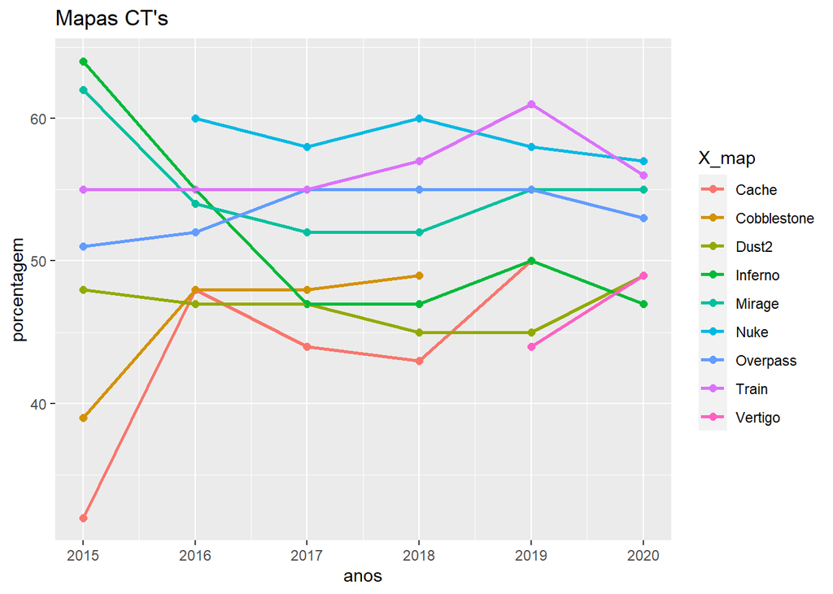

## Referências

[1] [Mercado de eSports: faturamento, audiência e o cenário no Brasil](https://ge.globo.com/sc/noticia/o-mercado-de-esports-faturamento-audiencia-e-o-cenario-no-brasil.ghtml)

[2] [Top 10 organizações mais valiosas no eSports - 13/04/2021](https://ge.globo.com/esports/stories/2021/04/13/as-10-organizacoes-mais-valiosas-nos-esportes-eletronicos.ghtml)